# final_R_reference

kato

2022-12-13

# R Reference Guide

## Loading Data and Packages

When attempting to use add-on packages that are not a part of the base R package, you must notify R that you want to use them using require() and library()

```r
library("palmerpenguins")
require(here)
```

Now the “palmerpenguins” data set and the here() command are ready to use!

If you would like to load in a csv file that is on your computer you can use read.csv() to choose the file and here() to bring it into your R workspace

```r
ginkgo = read.csv(here("data", "ginkgo_data_2022.csv"))
```

This creates a data frame with the data you loaded in.]

## Data Structures

The function c() combines or concatenates its arguments into a vector (a 1-dimensional data structure consisting of 1 or more elements). All of the elements must be of the same type. I can’t combine character and numeric types in the same call to c()

```r
## Create a vector of numbers:
num_vec  = c(1, 5, 8, 9, 13, 57)

## Create a vector of characters:
char_vec = c("a", "spiderz", "data is le epic swag")
```

The length() function is used to tell you the length/sum of items within a vector.

```r
## If I want to know how many items are in my vector of numbers I could simply:
 length(num_vec)
```

```
## [1] 6
```

```r
## I can do the same with my character vector:
length (char_vec)
```

```
## [1] 3
```

matrix() creates a matrix from a given set of values. * data = the data used to fill in the matric * nrow = # of rows * ncol = # of columns * byrow (TRUE/FALSE) = whether or not you want the matric to be sorted by row (true) or column(false)

```r
num_col = matrix(data = num_vec, nrow = 2, ncol = 3, byrow = FALSE)
print(num_col)
```

```
##      [,1] [,2] [,3]
## [1,]    1    8   13
## [2,]    5    9   57
```

```r
num_row = matrix(data = num_vec, nrow = 2, ncol = 3, byrow = TRUE)
print(num_row)
```

```
##      [,1] [,2] [,3]
## [1,]    1    5    8
## [2,]    9   13   57
```

Notice the difference of the organization?

data.frame() creates a table that display many different groups of data. Different columns can house different types of data but very column must have the same type of data. For example, lets say we work at a veterinarians office and we need to make a table for the patients we saw that day: Column 1 could be all characters: like the species of dog, Column 2 could be logical: like whether or not the dog had fleas, and column 3 for be numbers: like the dogs weight in pounds.

The structure is as follows:

```r
dog_data <- data.frame(
  dog_species = c("German Shephard","Boxer","Rottweiler","Yorkie","Jack Russel"),
  fleas_present = c(TRUE,FALSE, FALSE, TRUE, FALSE),
  dog_weight_lbs = c(80.4, 75.6, 100.5, 15.3, 20.6 )
)

print(dog_data)
```

```
##       dog_species fleas_present dog_weight_lbs
## 1 German Shephard          TRUE           80.4
## 2           Boxer         FALSE           75.6
## 3      Rottweiler         FALSE          100.5
## 4          Yorkie          TRUE           15.3
## 5     Jack Russel         FALSE           20.6
```

Now that you have created a data frame, it helps to be able to understand the dimensions of it. You can do that with the following functions:

```r
## to find the number of rows in a data set you can:
nrow(ginkgo)
```

```
## [1] 220
```

```r
## to find the number of columns in a data set you can:
ncol(ginkgo)
```

```
## [1] 6
```

```r
## and if you want to know both the row and column dimensions (IN THAT ORDER!) you can:
dim(ginkgo)
```

```
## [1] 220   6
```

## Subsetting

To retrieve a specific column from your data set you can call the name of the data frame and use the “$” symbol to specify the column you wish to view.This will print the data from that column as such:

```r
ginkgo$site_id
```

```
##   [1]   216   216   216   216   216   216   216   216   216   216  1896  1896
##  [13]  1896  1896  1896  1896  1896  1896  1896  1896  2183  2183  2183  2183
##  [25]  2183  2183  2183  2183  2183  2183  2187  2187  2187  2187  2187  2187
##  [37]  2187  2187  2187  2187  3469  3469  3469  3469  3469  3469  3469  3469
##  [49]  3469  3469  3470  3470  3470  3470  3470  3470  3470  3470  3470  3703
##  [61]  3703  3703  3703  3703  3703  3703  3703  3703  3703  3704  3704  3704
##  [73]  3704  3704  3704  3704  3704  3704  3704  3705  3705  3705  3705  3705
##  [85]  3705  3705  3705  3705  3705  4847  4847  4847  4847  4847  4847  4847
##  [97]  4847  4847  4847  4873  4873  4873  4873  4873  4873  4873  4873  4873
## [109]  4873  4874  4874  4874  4874  4874  4874  4874  4874  4874  4874  6066
## [121]  6066  6066  6066  6066  6066  6066  6066  6066  6066  6069  6069  6069
## [133]  6069  6069  6069  6069  6069  6069  6069  6069  6071  6071  6071  6071
## [145]  6071  6071  6071  6071  6071  6071  6718  6718  6718  6718  6718  6718
## [157]  6718  6718  6718  6718  6719  6719  6719  6719  6719  6719  6719  6719
## [169]  6719  6719  6721  6721  6721  6721  6721  6721  6721  6721  6721  6721
## [181]  9603  9603  9603  9603  9603  9603  9603  9603  9603  9603 12669 12669
## [193] 12669 12669 12669 12669 12669 12669 12669 12669 12978 12978 12978 12978
## [205] 12978 12978 12978 12978 12978 12978 12982 12982 12982 12982 12982 12982
## [217] 12982 12982 12982 12982
```

If you want to select a specific row/column based on their order you can use []. The format is as such: The first number represents the row number, and the second number represents the column number. If you wanted data from the first row and second column you would write [1,2]. If you only want data from a row or column, you can leave the other piece blank. Here is how you apply it:

```r
## we want ONLY row 1
ginkgo[1,]
```

```
##   site_id seeds_present max_width max_depth notch_depth petiole_length
## 1     216         FALSE        85        59          12             91
```

```r
## we want row 2, column 3
ginkgo[2,3]
```

```
## [1] 72
```

```r
## we want ONLY column 3
ginkgo[,3]
```

```
##   [1]  85  72  64  76  85  75  72  81  87  87  94  92  70  84  61 102  82  64
##  [19]  53  66  69  55  56  64  60  59  57  53  68  56  75  63  82  83  60  67
##  [37]  75  92 110  54  77  59  51 100  92  77  99  62  80  86  63  79  91  72
##  [55]  64  53  71  61  70  93  75  87  86  87  95  88  85  95  95  52  84  74
##  [73]  87  76  57  92  94  79  97  50 100  97  63  96  97  70  83  80  85 100
##  [91] 112 115  83 106  95  80 120  76  50  90  94  69  93  59  60 103  95  90
## [109]  80  90 106  98  73  89  65  83 116  90  86 104  92 103 100  91 102  99
## [127]  98 104  80  68  62  77  86  72  70  63  72  65  69  67  35  67  63  71
## [145]  77  60  70  69  55  72  84 106  61 114  95  86  60  78  86  91  79  95
## [163]  72 102  72 107  95  91  94  90  98  63  58  67  92  75  74  73  73  94
## [181]  76  86  78  74  89  77  80  71  69  81  39  60  50  47  52  61  56  45
## [199]  64  42 103  84 118 120 100 111 104  94  78  70  92  48  79  91 111  44
## [217] 117  93 101 145
```

To create a new data frame that applies to a certain criteria, you can use subset(). In this case, if I only wanted to look at data from Adelie penguins, I could drop any data that was associated with the other species.

```r
dat_adelie = droplevels(subset(penguins, species == "Adelie"))
```

## Numerical Data Exploration

If we want to create a summary of a data set that includes information such as: the min. and max., the quartiles, the mean, and the median we can use: summary(). Here is a summary of the ginkgo data.

```r
## this creates a summary of the entire data frame
summary(ginkgo)
```

```
##     site_id      seeds_present     max_width        max_depth
##  Min.   :  216   Mode :logical   Min.   : 35.00   Min.   : 24.0
##  1st Qu.: 3470   FALSE:180       1st Qu.: 67.00   1st Qu.: 45.0
##  Median : 4874   TRUE :40        Median : 80.00   Median : 53.0
##  Mean   : 5726                   Mean   : 79.95   Mean   : 53.1
##  3rd Qu.: 6719                   3rd Qu.: 93.00   3rd Qu.: 60.0
##  Max.   :12982                   Max.   :145.00   Max.   :125.0
##   notch_depth     petiole_length
##  Min.   : 0.000   Min.   : 13.00
##  1st Qu.: 0.000   1st Qu.: 45.00
##  Median : 2.000   Median : 58.00
##  Mean   : 5.977   Mean   : 59.51
##  3rd Qu.: 6.250   3rd Qu.: 71.00
##  Max.   :92.000   Max.   :126.00
```

If you want to find the mean of a group of data you can use: mean()

```r
## The mean maximum width of the ginkgo leaves is:
mean(ginkgo$max_width)
```

```
## [1] 79.95455
```

We can execute something similar to find the standard deviation of a group of data with: sd()

```r
## The standard deviation of maximum width of the ginkgo leaves is:
sd(ginkgo$max_width)
```

```
## [1] 18.16358
```

## Graphical Data Exploration

In order to visualize data, youll need to graph it. We can start out with a basic scatter plot using plot(). Lets plot max leaf depth (x) and max leaf width (y).

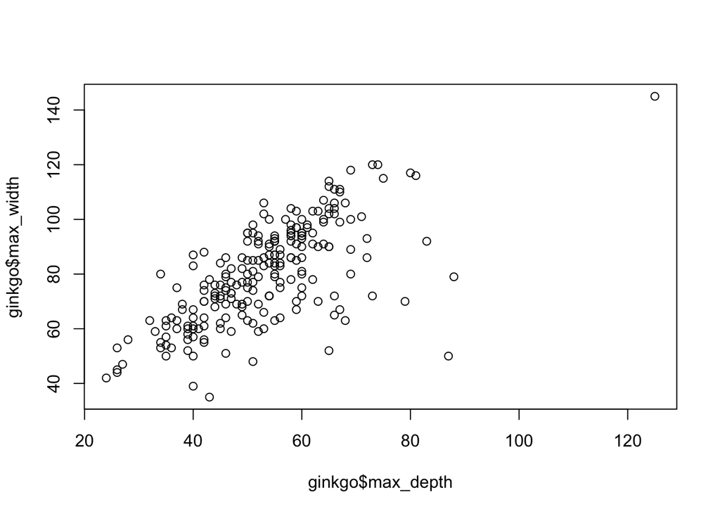

```r
## x is max leaf depth, y is max leaf width
plot(x = ginkgo$max_depth, y = ginkgo$max_width)
```

Now this is a cool graph, but it is missing a lot of crucial details and personalizations like a title, axis labels, etc. Let’s fix that!

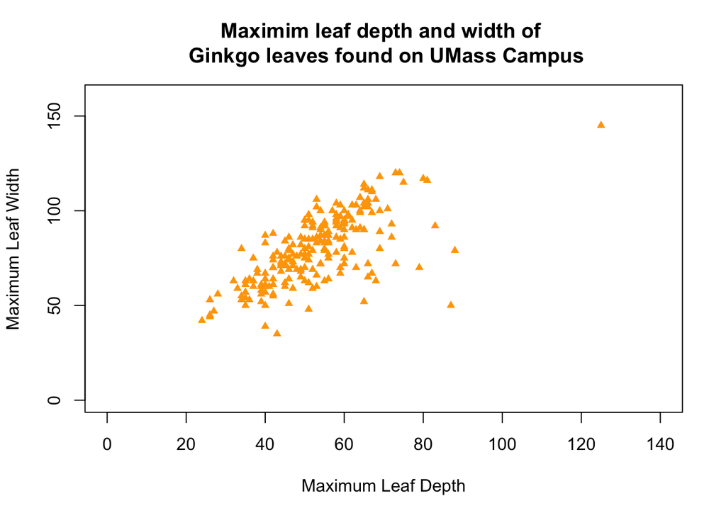

```r
## x is max leaf depth, y is max leaf width
plot(x = ginkgo$max_depth, y = ginkgo$max_width,
     ## the color of the data points. Enter your chosen color in parentheses or the hex code.
      col = "orange",
     ## the shape of the data points. The default is unshaded circles. I want mine to be triangles, so I will find the corresponding symbol and include it
      pch = 17,
     ## refers to the relative size of the text. The default is '1', and whatever you enter will be a permutation of that. I want the text to be 80% of the original size so I will do the following:
      cex = .8,
     ## Dictates the title of the graph. Always put it in quotation marks and use \n to create a new line
      main = "Maximim leaf depth and width of \n Ginkgo leaves found on UMass Campus",
     ## dictates the x axis label. our x axis is max depth
      xlab = "Maximum Leaf Depth",
     ## dictates the y axis label. our y axis is max width
      ylab = "Maximum Leaf Width",
     ## Dictates the size of the X-axis. If I want to extend the x-axiz past the default I can do so with this notation: range(min value, max value)
      xlim = range(0,140),
     ## Same as xlim, but on the y-axis
      ylim = range(0,160)
       )
```

If we wanted to make a histogram we could do this:

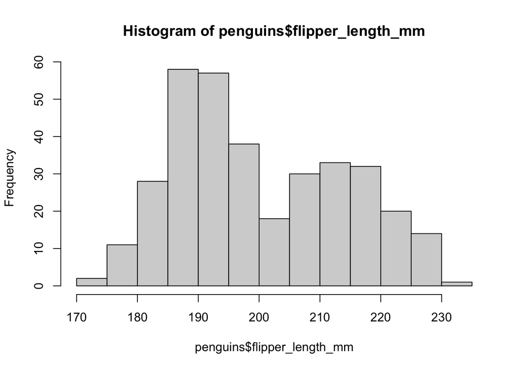

```r
hist(penguins$flipper_length_mm)
```

Again, this is a bit lackluster. Lets personalize this

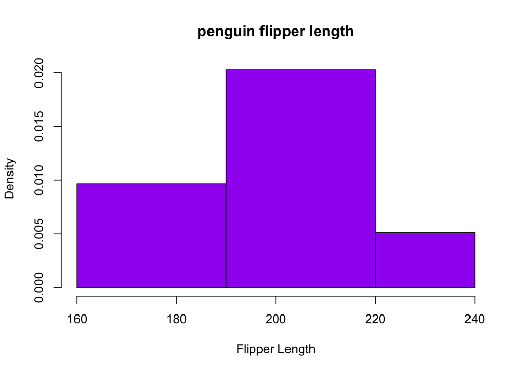

```r
hist(penguins$flipper_length_mm,
  ## we know these from the last one:
  col = "purple",
  cex = .8,
  main = "penguin flipper length",
  xlab = "Flipper Length",
  ## the "breaks" arguments dictates the bin organization of the histogram. I am going to make the bins far too big to illustrate the usage!
  breaks =c(160,190, 220, 240))
```

Now if we wanted to make a boxplot, we could do this:

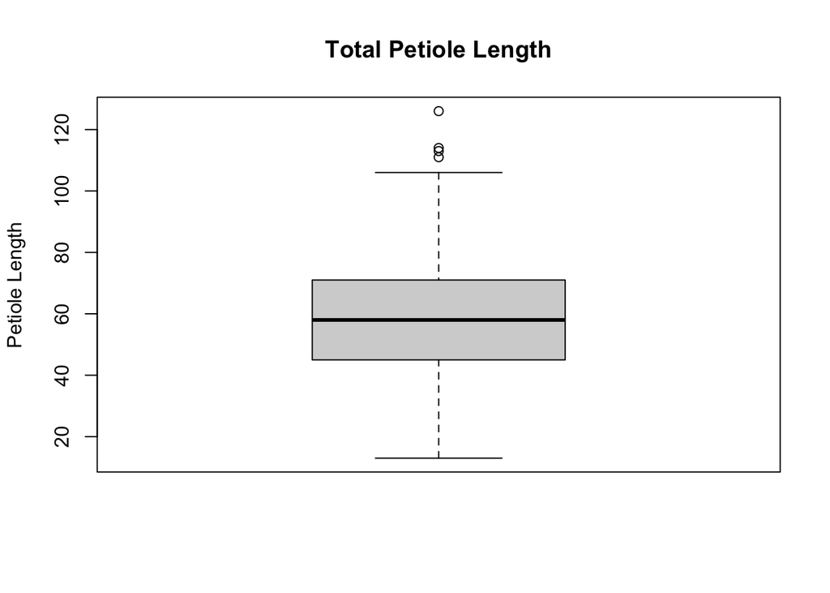

```r
## blox plot of petiole length
boxplot(ginkgo$petiole_length, main = "Total Petiole Length", ylab = "Petiole Length")
```

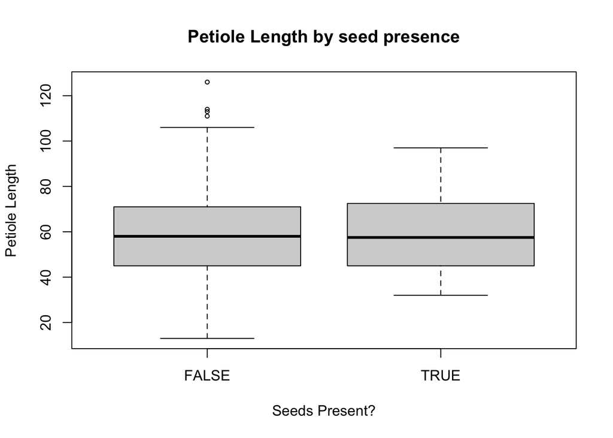

```r
## boxplot of petiole length conditioned on whether or not seeds were present on the tree
boxplot(petiole_length ~ seeds_present, dat = ginkgo, main ="Petiole Length by seed presence", cex = .6, ylab = "Petiole Length", xlab = "Seeds Present?")
```

If we wanted to create a panel of multiple graphs, we can using this method:

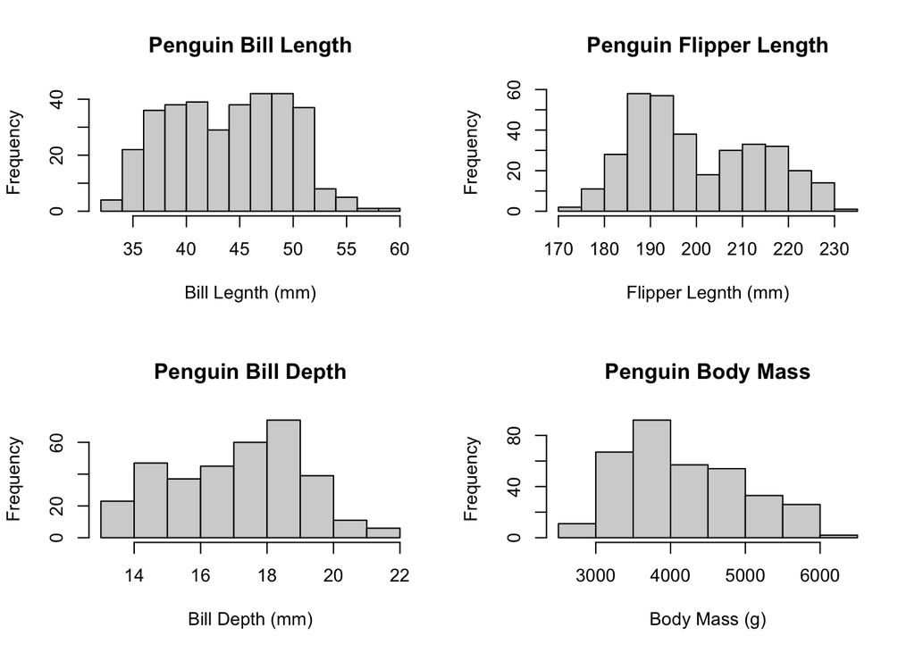

```r
## to put the graphs on a 4 graph panel in a 2/2 grid, we can use par(mfrow = c(# of rows, # of columns)). In this case I want 2 rows and 2 columns
par(mfrow = c(2,2))
hist(penguins$bill_length_mm, main = "Penguin Bill Length", xlab = "Bill Legnth (mm)")
hist(penguins$flipper_length_mm, main = "Penguin Flipper Length",  xlab = "Flipper Legnth (mm)")
hist(penguins$bill_depth_mm, main = "Penguin Bill Depth",  xlab = "Bill Depth (mm)")
hist(penguins$body_mass_g, main = "Penguin Body Mass",  xlab = "Body Mass (g)")
```